# HW2_SERCAN_BÖÇKÜN_2019402123

```r
data$one_lagged_sales = data[,.(two_lagged_sales = shift(data$Unleaded.Gasoline.Sale..UGS., n=1L, fill=NA))]

data[,.(four_lagged_sales = shift(data$Unleaded.Gasoline.Sale..UGS., n=4L, fill=NA))]
```

```
##     four_lagged_sales
##  1:                NA
##  2:                NA
##  3:                NA
##  4:                NA
##  5:           1128971
##  6:           1199569
##  7:           1370167
##  8:           1127548
##  9:           1033918
## 10:           1019754
## 11:           1209916
## 12:           1002789
## 13:            893722
## 14:           1027252
```

[output cut: 19 more lines]

```r
data$four_lagged_sales = data[,.(four_lagged_sales = shift(data$Unleaded.Gasoline.Sale..UGS., n=4L, fill=NA))]
```

We added the 4 and 1 time interval lagged y(t)’s to their corresponding rows. The previous model had a high autocorrelation with a lag of 1. Let’s add one_lagged_sales to the model

```r
model_3= lm(Unleaded.Gasoline.Sale..UGS.~trend + seasonality
            + Price.of.Diesel.Gasoline..PG.+
              X..Unleaded.Gasoline.Vehicles..NUGV. + X..of.Diesel.Gasoline.Vehicles..NDGV.
            + GNP.Commerce + one_lagged_sales  , data)
summary(model_3)
```

```
##
## Call:
## lm(formula = Unleaded.Gasoline.Sale..UGS. ~ trend + seasonality +
##     Price.of.Diesel.Gasoline..PG. + X..Unleaded.Gasoline.Vehicles..NUGV. +
##     X..of.Diesel.Gasoline.Vehicles..NDGV. + GNP.Commerce + one_lagged_sales,
##     data = data)
##
## Residuals:
##    Min     1Q Median     3Q    Max
## -38741 -11707  -1491  13619  42562
##
## Coefficients:
##                                         Estimate Std. Error t value Pr(>|t|)
## (Intercept)                            2.327e+06  6.883e+05   3.382  0.00355 **
## trend                                 -1.652e+04  7.453e+03  -2.216  0.04060 *
## seasonality2                           1.128e+04  5.733e+04   0.197  0.84637
## seasonality3                           1.262e+05  1.217e+05   1.036  0.31451
## seasonality4                           1.212e+05  6.276e+04   1.932  0.07026 .
## Price.of.Diesel.Gasoline..PG.         -9.394e+02  2.393e+02  -3.925  0.00109 **
## X..Unleaded.Gasoline.Vehicles..NUGV.  -5.496e-01  2.531e-01  -2.171  0.04436 *
## X..of.Diesel.Gasoline.Vehicles..NDGV.  7.618e+03  2.528e+03   3.013  0.00783 **
## GNP.Commerce                           7.864e-02  5.237e-02   1.502  0.15154
## one_lagged_sales                      -6.150e-01  2.235e-01  -2.751  0.01364 *
## ---
## Signif. codes:  0 '***' 0.001 '**' 0.01 '*' 0.05 '.' 0.1 ' ' 1
##
## Residual standard error: 27330 on 17 degrees of freedom
##   (5 observations deleted due to missingness)
## Multiple R-squared:  0.9787, Adjusted R-squared:  0.9674
## F-statistic: 86.66 on 9 and 17 DF,  p-value: 2.02e-12
```

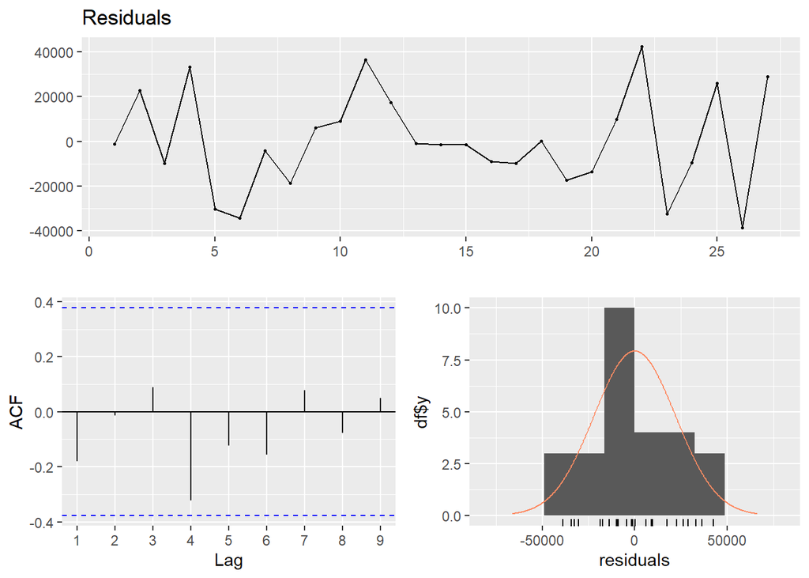

```r
checkresiduals(model_3$residuals)
```

The high autocorrelation with lag 1 is ommitted with the addition of 1 lagged output data ACF values are currently below the upper and lower limits. However significance of other variables reduced. Let’s drop insignificant variables from the model except the seasonality. Even though seasonality variable is insignificant, when it’s reduced there occurs spikes in autocorrelation of residuals with period of 4 despite the little increase in the Adj R^2. For that reason we will keep it in the model for the sake of normality of our residuals.

```r
model_4= lm(Unleaded.Gasoline.Sale..UGS.~trend + seasonality
            + Price.of.Diesel.Gasoline..PG.+
              X..Unleaded.Gasoline.Vehicles..NUGV. + X..of.Diesel.Gasoline.Vehicles..NDGV.
          + one_lagged_sales  , data)
summary(model_4)
```

```
##
## Call:
## lm(formula = Unleaded.Gasoline.Sale..UGS. ~ trend + seasonality +
##     Price.of.Diesel.Gasoline..PG. + X..Unleaded.Gasoline.Vehicles..NUGV. +
##     X..of.Diesel.Gasoline.Vehicles..NDGV. + one_lagged_sales,
##     data = data)
##
## Residuals:
##    Min     1Q Median     3Q    Max
## -43631 -13550  -3959  20638  42723
##
## Coefficients:
##                                         Estimate Std. Error t value Pr(>|t|)
## (Intercept)                            2.803e+06  6.319e+05   4.436 0.000319
## trend                                 -6.720e+03  3.724e+03  -1.804 0.087931
## seasonality2                           8.955e+04  2.469e+04   3.626 0.001930
## seasonality3                           3.071e+05  1.790e+04  17.161 1.33e-12
## seasonality4                           1.928e+05  4.224e+04   4.564 0.000240
## Price.of.Diesel.Gasoline..PG.         -7.836e+02  2.231e+02  -3.513 0.002486
## X..Unleaded.Gasoline.Vehicles..NUGV.  -7.773e-01  2.097e-01  -3.707 0.001614
## X..of.Diesel.Gasoline.Vehicles..NDGV.  9.833e+03  2.123e+03   4.631 0.000208
## one_lagged_sales                      -4.504e-01  2.015e-01  -2.235 0.038316
##
## (Intercept)                           ***
## trend                                 .
## seasonality2                          **
## seasonality3                          ***
## seasonality4                          ***
## Price.of.Diesel.Gasoline..PG.         **
## X..Unleaded.Gasoline.Vehicles..NUGV.  **
## X..of.Diesel.Gasoline.Vehicles..NDGV. ***
## one_lagged_sales                      *
## ---
## Signif. codes:  0 '***' 0.001 '**' 0.01 '*' 0.05 '.' 0.1 ' ' 1
##
## Residual standard error: 28260 on 18 degrees of freedom
##   (5 observations deleted due to missingness)
## Multiple R-squared:  0.9758, Adjusted R-squared:  0.9651
## F-statistic: 90.88 on 8 and 18 DF,  p-value: 5.777e-13
```

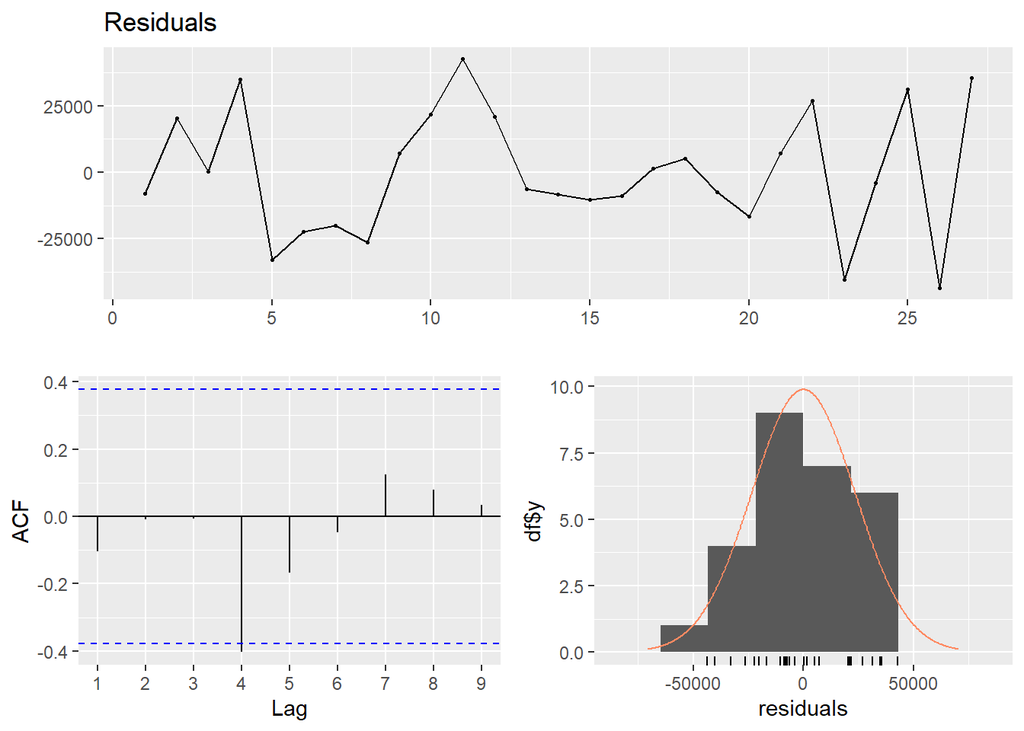

```r
checkresiduals(model_4$residuals)
```

We have dropped the “GNP.Commerce” variable since it was found to be insignificant from the t test. Looking at the residuals and it’s autocorrelation, we still see some negative autocorrelation with lag of 4. We might consider to add four_lagged_sales to the model.

```r
model_5= lm(Unleaded.Gasoline.Sale..UGS.~trend + seasonality
            + Price.of.Diesel.Gasoline..PG.+
              X..Unleaded.Gasoline.Vehicles..NUGV. + X..of.Diesel.Gasoline.Vehicles..NDGV.
            + one_lagged_sales + four_lagged_sales , data)
summary(model_5)
```

```
##
## Call:
## lm(formula = Unleaded.Gasoline.Sale..UGS. ~ trend + seasonality +
##     Price.of.Diesel.Gasoline..PG. + X..Unleaded.Gasoline.Vehicles..NUGV. +
##     X..of.Diesel.Gasoline.Vehicles..NDGV. + one_lagged_sales +
##     four_lagged_sales, data = data)
##
## Residuals:
##    Min     1Q Median     3Q    Max
## -44105 -15706  -5382  14675  45964
##
## Coefficients:
##                                         Estimate Std. Error t value Pr(>|t|)
## (Intercept)                            2.931e+06  9.405e+05   3.117  0.00757
## trend                                 -9.953e+03  5.839e+03  -1.705  0.11033
## seasonality2                           1.090e+05  3.501e+04   3.113  0.00763
## seasonality3                           3.495e+05  6.449e+04   5.419 9.04e-05
## seasonality4                           2.076e+05  5.380e+04   3.859  0.00174
## Price.of.Diesel.Gasoline..PG.         -7.160e+02  2.563e+02  -2.794  0.01436
## X..Unleaded.Gasoline.Vehicles..NUGV.  -7.958e-01  3.729e-01  -2.134  0.05101
## X..of.Diesel.Gasoline.Vehicles..NDGV.  1.033e+04  4.165e+03   2.481  0.02642
## one_lagged_sales                      -4.578e-01  2.310e-01  -1.982  0.06748
## four_lagged_sales                     -1.664e-01  2.117e-01  -0.786  0.44488
##
## (Intercept)                           **
## trend
## seasonality2                          **
## seasonality3                          ***
## seasonality4                          **
## Price.of.Diesel.Gasoline..PG.         *
## X..Unleaded.Gasoline.Vehicles..NUGV.  .
## X..of.Diesel.Gasoline.Vehicles..NDGV. *
## one_lagged_sales                      .
## four_lagged_sales
## ---
## Signif. codes:  0 '***' 0.001 '**' 0.01 '*' 0.05 '.' 0.1 ' ' 1
##
## Residual standard error: 30570 on 14 degrees of freedom
##   (8 observations deleted due to missingness)
## Multiple R-squared:  0.9629, Adjusted R-squared:  0.939
## F-statistic: 40.35 on 9 and 14 DF,  p-value: 1.756e-08
```

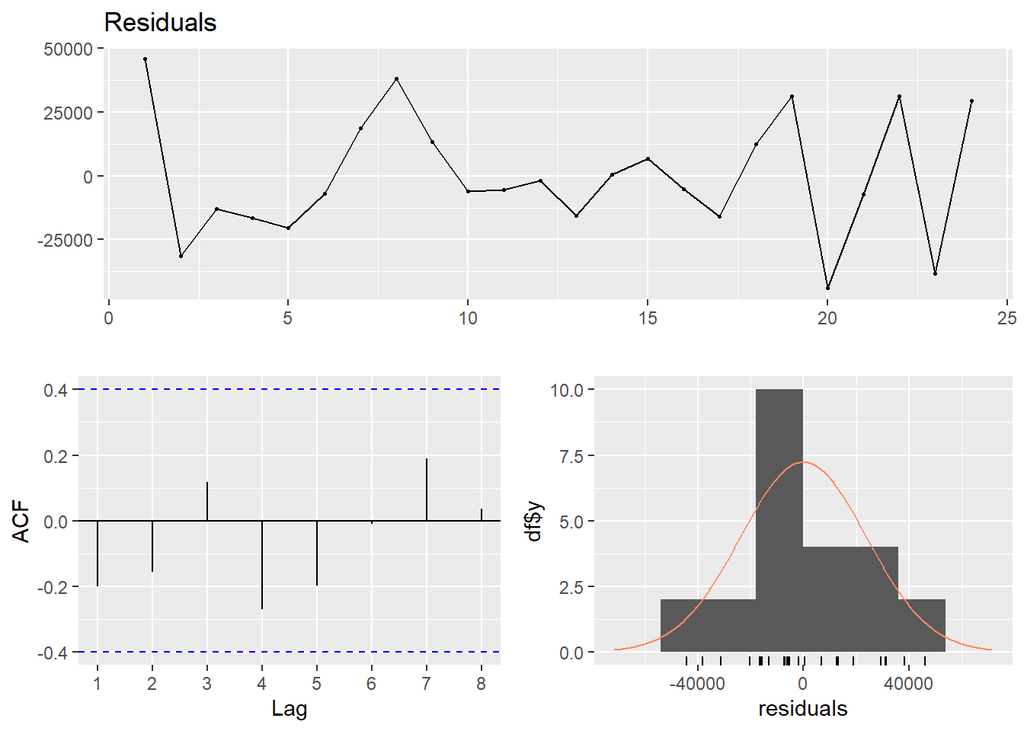

```r
checkresiduals(model_5$residuals)
```

We have added the four_lagged_sales to the model in order to reduce the autocorrelation with the lag of 4 but contrary to our expectation this variable is found to be insignificant from the t test and our model’s adjusted R^2 is reduced heavily. In conclusion we will select the model_4 as our main model.

## 5. Final Model

```r
summary(model_4)
```

```
##
## Call:
## lm(formula = Unleaded.Gasoline.Sale..UGS. ~ trend + seasonality +
##     Price.of.Diesel.Gasoline..PG. + X..Unleaded.Gasoline.Vehicles..NUGV. +
##     X..of.Diesel.Gasoline.Vehicles..NDGV. + one_lagged_sales,
##     data = data)
##
## Residuals:
##    Min     1Q Median     3Q    Max
## -43631 -13550  -3959  20638  42723
##
## Coefficients:
##                                         Estimate Std. Error t value Pr(>|t|)
## (Intercept)                            2.803e+06  6.319e+05   4.436 0.000319
## trend                                 -6.720e+03  3.724e+03  -1.804 0.087931
## seasonality2                           8.955e+04  2.469e+04   3.626 0.001930
## seasonality3                           3.071e+05  1.790e+04  17.161 1.33e-12
## seasonality4                           1.928e+05  4.224e+04   4.564 0.000240
## Price.of.Diesel.Gasoline..PG.         -7.836e+02  2.231e+02  -3.513 0.002486
## X..Unleaded.Gasoline.Vehicles..NUGV.  -7.773e-01  2.097e-01  -3.707 0.001614
## X..of.Diesel.Gasoline.Vehicles..NDGV.  9.833e+03  2.123e+03   4.631 0.000208
## one_lagged_sales                      -4.504e-01  2.015e-01  -2.235 0.038316
##
## (Intercept)                           ***
## trend                                 .
## seasonality2                          **
## seasonality3                          ***
## seasonality4                          ***
## Price.of.Diesel.Gasoline..PG.         **
## X..Unleaded.Gasoline.Vehicles..NUGV.  **
## X..of.Diesel.Gasoline.Vehicles..NDGV. ***
## one_lagged_sales                      *
## ---
## Signif. codes:  0 '***' 0.001 '**' 0.01 '*' 0.05 '.' 0.1 ' ' 1
##
## Residual standard error: 28260 on 18 degrees of freedom
##   (5 observations deleted due to missingness)
## Multiple R-squared:  0.9758, Adjusted R-squared:  0.9651
## F-statistic: 90.88 on 8 and 18 DF,  p-value: 5.777e-13
```

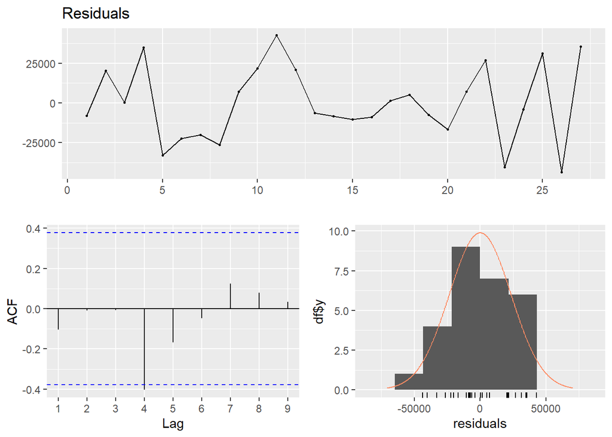

```r
checkresiduals(model_4$residuals)
```

Our final model’s residual’s autocorrelation values are within the decided upper and lower limits except the slight breach of the lower limit at the lag 4. Model’s Adj R^2 is 0.9651 and residuals are distribution can be estimated to be normal. Most of our variables are mostly significant and our least significant variable has a p value of 0.088 which can be considered somewhat significant

## 6. Making Predictions

The time to make predictions for the quarters in 2007 has come. Before diving deep into the predictions one thing should be clarified. Predicting the sales in the rows of 2007_Q2, 2007_Q3, 2007_Q4 is challenging since these rows do not have the data of “previous year’s sales”, these data points are blank and model cannot do predictions for these data points. We will put in model’s sales prediction for the “2007_Q1” as the “previous year’s sales” data point to the “2007_Q2”, “2007_Q2” to the “2007_Q3” and “2007_Q3” to the “2007_Q4”

```r
tmp=copy(data)

tmp[,actual:=Unleaded.Gasoline.Sale..UGS.]
tmp[,predictions:=predict(model_4,tmp)]
print(tmp)
```

```
##     Quarter Unleaded.Gasoline.Sale..UGS.   RNUV X..LPG.Vehicles..NLPG.
##  1: 2000_Q1                      1128971 0.0146                 940000
##  2: 2000_Q2                      1199569 0.0205                 941000
##  3: 2000_Q3                      1370167 0.0207                 943500
##  4: 2000_Q4                      1127548 0.0163                 948000
##  5: 2001_Q1                      1033918 0.0071                 950000
##  6: 2001_Q2                      1019754 0.0051                 955000
##  7: 2001_Q3                      1209916 0.0041                 967500
##  8: 2001_Q4                      1002789 0.0048                 990000
##  9: 2002_Q1                       893722 0.0012                1000000
## 10: 2002_Q2                      1027252 0.0032                1001000
## 11: 2002_Q3                      1153265 0.0034                1003500
## 12: 2002_Q4                       991981 0.0044                1008000
## 13: 2003_Q1                       806257 0.0019                1010000
## 14: 2003_Q2                       960556 0.0056                1048000
```

[output cut: 155 more lines]

```r
tmp[ 30, "one_lagged_sales"] = 66210.0
tmp[,predictions2:=predict(model_4,tmp)]


tmp[ 31, "one_lagged_sales"] = 1110417.4
tmp[,predictions2:=predict(model_4,tmp)]


tmp[ 32, "one_lagged_sales"] = 848645.6
tmp[,predictions2:=predict(model_4,tmp)]
```

## 7. Predictions

```r
print(tmp$predictions2)
```

```
##  [1]        NA 1207534.6 1349903.8 1127286.7  999040.5 1052700.4 1232145.8
##  [8] 1022963.2  920186.6 1020094.3 1131526.1  949258.0  785243.8  966780.9
## [15] 1113109.4  944420.5  841115.3  973615.6 1089653.1  861990.6  779260.5
## [22]  883527.4 1013972.4  833722.4  740539.3  846349.8  990414.4  836614.5
## [29]  666210.0 1110417.4  848645.6  845204.5
```

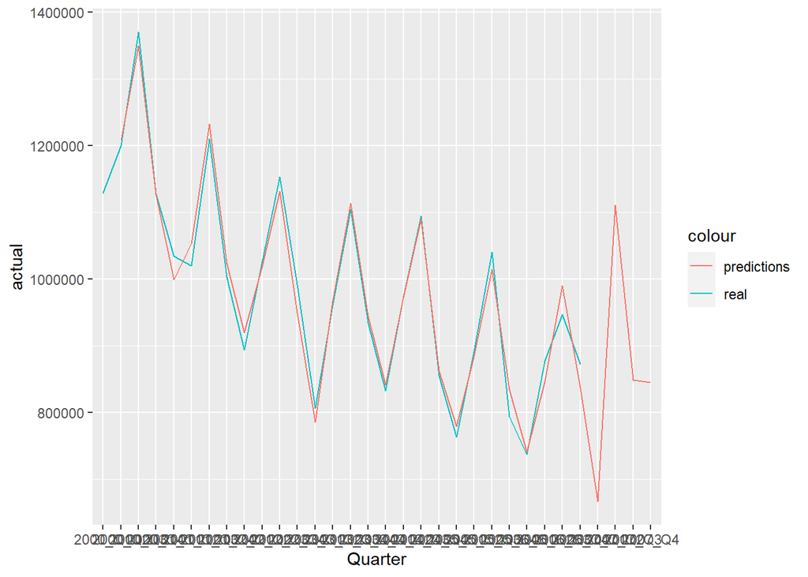

```r
ggplot(tmp ,aes(x=Quarter)) +
  geom_line(aes(y=actual,color='real', group = 1)) +
  geom_line(aes(y=predictions2, color = 'predictions', group = 1) )
```